# How do we determine what works?

Adam La Caze

Semester 1, 2023

## Objectives

- Be able to discuss causal concepts
- Be able to describe the key aspects of common study designs used in clinical epidemiology
- Be able to describe key types of bias: confounding, selection bias and information bias
- Be able to describe the strengths and weaknesses of different study designs in clinical epidemiology

## Key concepts

- Clinical epidemiology is focussed on **estimating** the effects of interventions (e.g. estimating the difference a drug makes to an outcome)
- **Bias** is any **systematic error** in estimating an effect
- **Confounding** occurs when an extraneous risk factor is associated with both **exposure** and **outcome**
- Randomized trials possess superior methods for reducing confounding

We determine an intervention **works** when we observe benefits from the intervention in studies that utilise methods that minimise all likely sources of error.

# Causation

## Causal skepticism

- ‘Correlation doesn’t imply causation’
- Causal inferences/conclusions ‘go beyond the data’
- To make a causal conclusion you need to make some causal assumptions

## What do people mean when they say $A$ causes $B$?

- There is a **mechanism** that links $A$ and $B$
- $A$ (or a change in $A$) **makes a difference** to $B$

## Causation in medicine

> …causal claims need to be made on the basis of evidence of both **difference-making** (statistical associations, randomised controlled trials etc.) and **mechanisms**…

Russo and Williamson (2011, 568)

## Clinical pharmacology

> The science of drugs and their clinical use. It is underpinned by the basic science of pharmacology, with an added focus on the application of pharmacological principles and quantitative methods in the real world ([Wikipedia](https://en.wikipedia.org/wiki/Clinical_pharmacology))

There is a particular focus on understanding the mechanisms by which drugs effect patients.

## Clinical epidemiology

> The science of making predictions about individual patients by counting clinical events [death, disease, discomfort, disability, dissatisfaction] in groups of similar patients and using strong scientific methods to ensure that the predictions are accurate.

Fletcher et al. (2014, 3)

Clinical epidemiology is focused on measuring the difference that an intervention makes on clinical outcomes. It relies heavily on statistics.

## Causal graphs

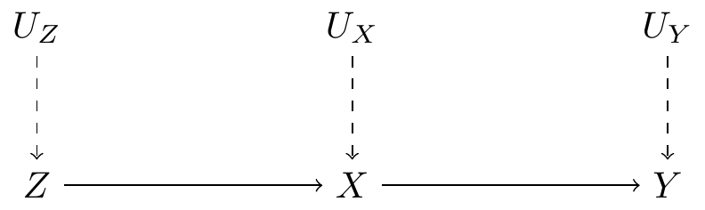

$Z$, $X$ and $Y$ are measured variables (e.g. preference for treatment, treatment and outcome, respectively). $U_Z$, $U_X$ and $U_Y$ are unmeasured variables that influence $Z$, $X$ and $Y$, respectively. Arrows represent assumed causal relationships, e.g. $Z$ is a cause of $X$. The absence of an arrow represents the assumption that the the variables are independent, e.g. $U_Z$ and $U_X$.

## Causal graphs: intervention

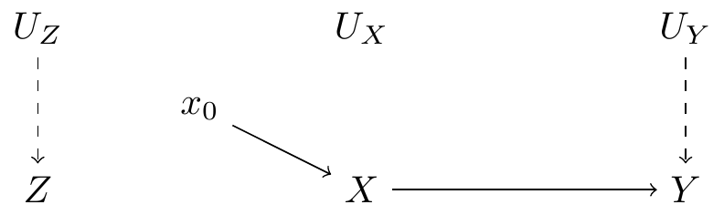

We intervene on $X$ by setting it to a specific value in a randomized trial (i.e. receive treatment, or not receive treatment). Intervening on $X$ in this way ‘screens off’ the influence of $Z$ and $U_X$ on $X$ and allows us to directly measure the influence of $X$ on $Y$.

## Causal graphs can be helpful to…

- Represent and test causal assumptions
- Identify appropriate methods to assess causal claims
- Think about potential sources of bias for specific studies and strategies for remedying that bias

# Clinical epidemiology

## Types of error

**Random error**

occurs when an observed result is different to the true result due to the play of chance.

**Systematic error**

occurs when an observed result is different to the true result because of an inaccuracy in observation or measurement inherent in the methods being employed (e.g. unexpected differences in the groups that are being compared)

## Avoiding error

**Error** and the **tools of clinical epidemiology** are two sides of the same coin.

- We reduce **random error** through statistical approaches
- We reduce **systematic error** through methods

## Bias

Bias refers to any **systematic error** in **estimating** the effect of a drug, exposure or risk factor on a specified outcome

## Bias Concept Map

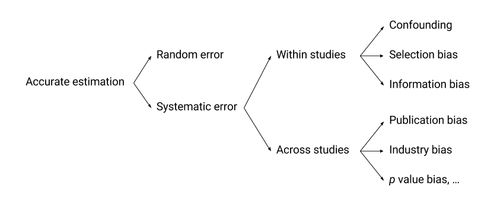

Rothman et al (2008), p. 128, with modification

## Confounding

**Confounding (informal)**

Confounding occurs when two factors are associated with each other, or “travel together” and the effect of one is confused with or distorted by the effect of the other.

Fletcher, Fletcher, and Wagner (1996, 8)

**Confounding (formal)**

Necessary conditions for a factor to be a **confounding factor** between exposure and outcome:

1. The factor must be an extraneous risk factor for the outcome
2. The factor must be associated with the exposure under study in the source population
3. The factor cannot be an intermediate step in the causal path between the exposure and the outcome

Rothman, Greenland, and Lash (2008, 132–34)

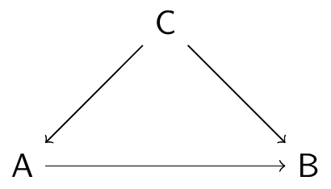

$C$ is a confounder in the relationship between $A$ and $B$

## Why confounding matters

Hormone replacement therapy

- From 1980–2000 many women were prescribed long-term hormone replacement therapy to reduce cardiovascular disease
- This practice was backed-up by what what was understood about the mechanisms and several large observational studies

> The preponderance of evidence from epidemiological studies strongly supports the view that postmenopausal oestrogen therapy **can substantially reduce the risk of coronary heart disease**. …This effect is unlikely to be explained by confounding factors or selection.

Stampfer and Colditz (1991, 61)

## Women’s Health Initiative

- The Women’s Health Initiative study (2003) randomized 16,608 postmenopausal women to HRT or placebo and followed them for 5 years
- Overall hazard ratio for coronary heart disease 1.24 (95% unadjusted CI: 1.00–1.54)
- Women randomized to HRT **suffered an additional 6 cases of coronary heart disease per 10,000 person-years**

How do we explain the very different results?

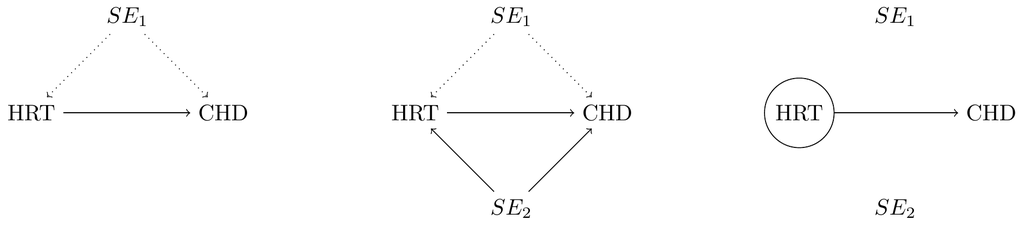

The relationship between HRT and CHD

- Left-most: what we thought was happening in the cohort studies
- Middle: what really was happening in the cohort studies
- Right-most: what happens when you randomize

## Selection bias

**Selection bias**

Errors in estimation that result from the procedures used to select subjects and from factors that influence study participation

If we want to estimate the effects of HRT on CHD in a case-control study and women who have taken HRT and experienced CHD are more likely to participate in the study compared to other women, the study would suffer from selection bias.

## Information bias

**Information bias**

Bias that arises due to measurement error in the variables used in the analysis

Consider a study using dispensing records to identify women exposed to HRT. HRT is taken for several indications. If women taking HRT for indications other than perimenopausal symptoms or perceived cardioprotection are included in the sample and this influenced the findings, then this would be a form of information bias.

# Study designs

## Addressing bias through study design

- The key to addressing within-study bias is **study design** and employing specific **methods** within study designs
- **Random allocation** and methods that are available with random allocation, e.g. masking, intention-to-treat analysis, …, are important for addressing within-study bias
- When random allocation is unavailable: Careful selection of participants (cases/controls) and/or covariates for adjustment, …

## Randomized trials

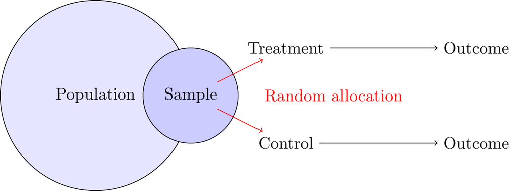

Key design aspects of a randomized controlled trial

## Cohort studies

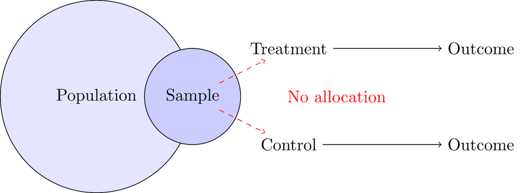

Key design aspects of a cohort study

## Case-control studies

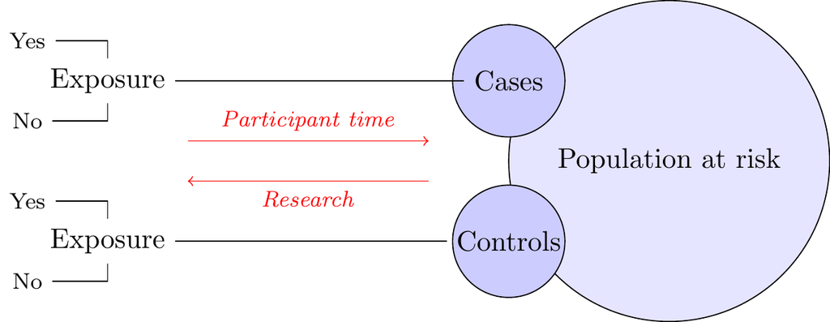

Key design aspects of a case-control study

See lecture notes for a discussion of the strengths and weaknesses of the designs.

## References

Fletcher, Robert H, Suzanne W Fletcher, Grant S Fletcher, (Robert Hillman) Fletcher Robert H., Suzanne W (Suzanne Wright) Fletcher, and Grant S Fletcher. 2014. *Clinical Epidemiology the Essentials*. 5th editio. Philadelphia, Pennsylavania: Wolters Kluwer Health : Lippincott Williams & Wilkins.

Fletcher, Robert H, Suzanne W Fletcher, and Edward H Wagner. 1996. *Clinical Epidemiology: The Essentials*.

Rothman, Kenneth J, Sander Greenland, and Timothy L. Lash. 2008. “Validity in Epidemiologic Studies.” In *Modern Epidemiology*, edited by Kenneth J Rothman, Sander Greenland, and Timothy L Lash, 3rd ed., 128–47. Philadelphia: Lippincott Williams & Wilkins. https://doi.org/10.1016/B978-0-443-06954-3.00009-8.

Russo, Federica, and Jon Williamson. 2011. “Epistemic Causality and Evidence-Based Medicine.” *History and Philosophy of the Life Sciences* 33 (4): 563–81.

Stampfer, M J, and G A Colditz. 1991. “Estrogen Replacement Therapy and Coronary Heart Disease: A Quantitative Assessment of the Epidemiologic Evidence.” *Preventive Medicine* 20 (1): 47–63.

Women’s Health Initiative Investigators. 2003. “Estrogen Plus Progestin and the Risk of Coronary Heart Disease.” *New England Journal of Medicine* 349 (6): 523–34. https://doi.org/10.1056/NEJMoa1404304.